# Project: No-show appointments

### by Nervana Mosaad

[figure not shown]

## Introduction

This dataset collects information from 100k medical appointments in **Brazil** and is focused on the question of whether or not patients show up for their appointment. A number of characteristics about the patient are included in each row. It provides us information about *patient ID*, gender, the day patient registered an appointment(Scheduled day), the day when patient has to visit the doctor(Appointment day), age of patient, neighbourhood (where patient will visit doctor), scholarship(indicates whether or not the patient is enrolled in Brasilian welfare program [Bolsa Família.](https://en.wikipedia.org/wiki/Bolsa_Fam%C3%ADlia), chornic diseases (hipertension, diabetes, handcap, alcoholism).

Here is the variables we will discuss [No-show appointments.](https://d17h27t6h515a5.cloudfront.net/topher/2017/October/59dd2e9a_noshowappointments-kagglev2-may-2016/noshowappointments-kagglev2-may-2016.csv)

You can see [original source on Kaggle](https://www.kaggle.com/datasets/joniarroba/noshowappointments) to know more about the dataset and columns.

## Exploratory Data Analysis

### Research Question 1

### What factors are important for us to know in order to predict if a patient will show up for their scheduled appointment?

## Summary of patient's age

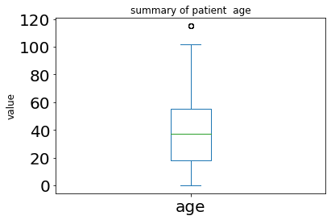

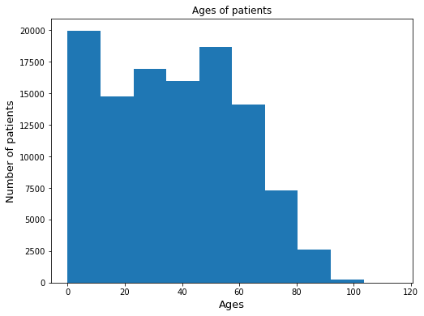

### Research Question 2

### What is the life stage have maximum number of patients?

- Infant = 0-1 year
- Toddler = 2-4 yrs
- Child = 5-12 yrs
- Teen = 13-19 yrs
- Adult = 20-39 yrs
- Middle Age Adult = 40-59 yrs
- Senior Adult = 60+

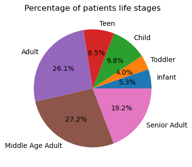

# Genders in the dataset.

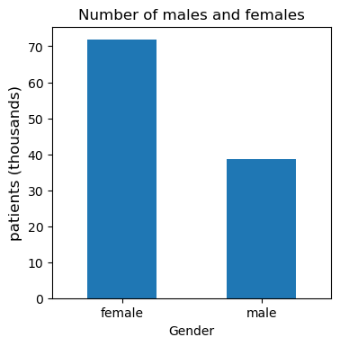

# What is the relationship between different diseases and patient life stage?

- Hypertension
- Diabetes
- Alcoholism
- Handcap

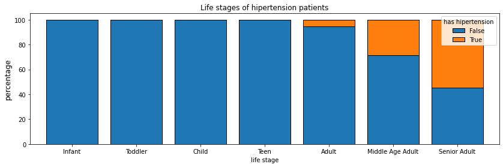

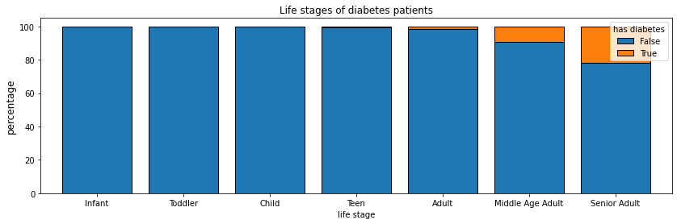

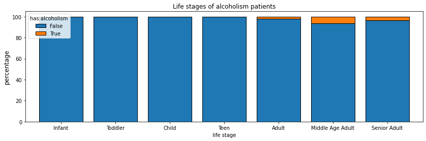

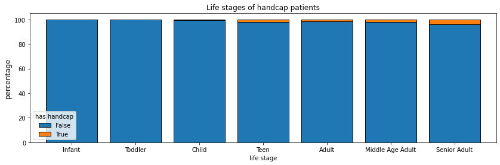

# Let's also show the relationship between different diseases and patient life stages in each gender separately for comparison.

- Hypertension
- Diabetes
- Alcoholism
- Handcap

### in males / females

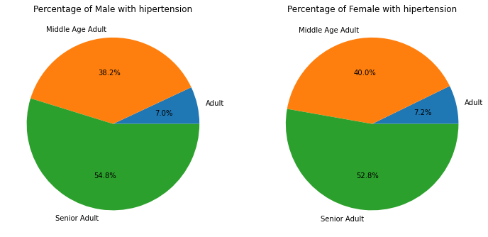

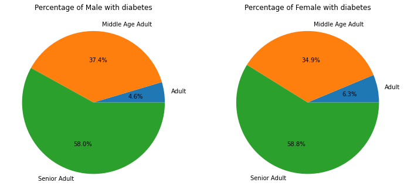

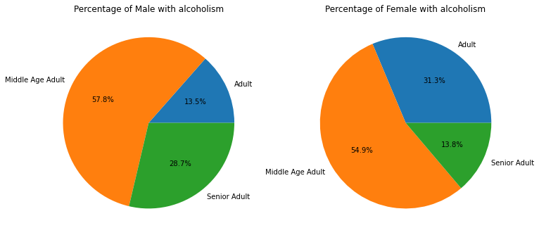

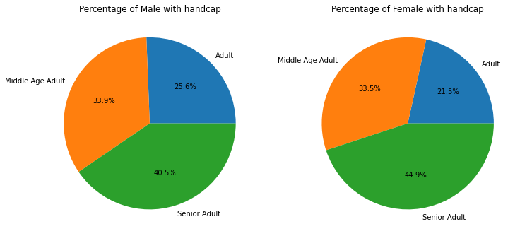

#### Again, we can see the same results obviously.

# What is the top ten neighborhoods whose patients have scholarships?

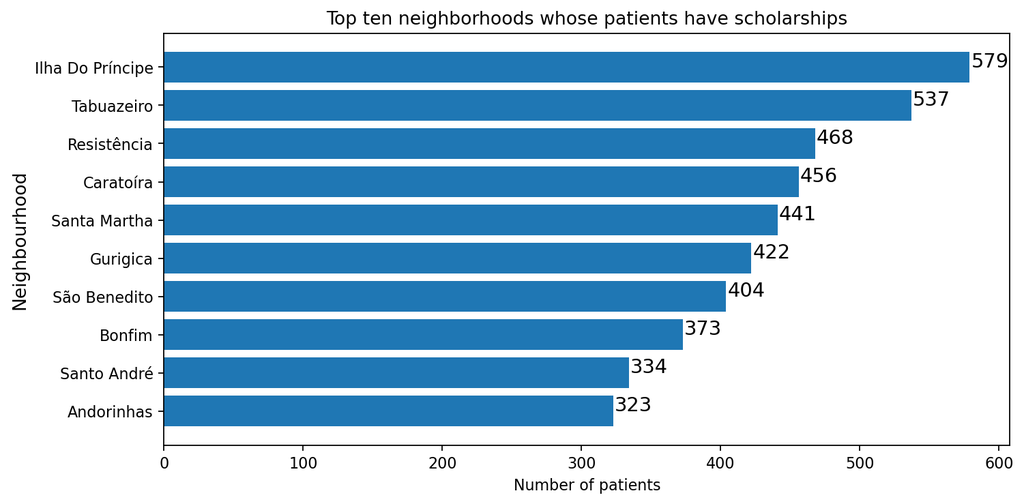

# The maximum number of visits to one neighborhood.

```
Patient of the maximum number of visits hospital went 87 times.
```

# How many males and females have all diseases?

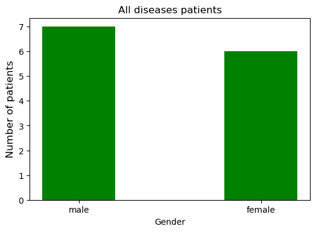

- There are 7 males and 6 females who had all diseases in the dataset.

# Is the scholarship related with a specific patient feature or even a disease?

- Contrary to expected and according to analyses, it is shown that the scholarship is completely unrelated to any specific feature of patients.

# What is the ratio of people attending and missing appointment?

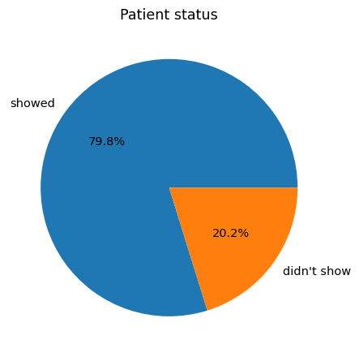

# Does waiting time interval have any effect on people showing up for appointment?

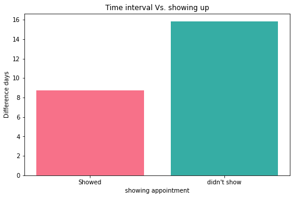

- It seems that in general, patients with more days difference between scheduled day appointment days would cancel their appointment.
- However..

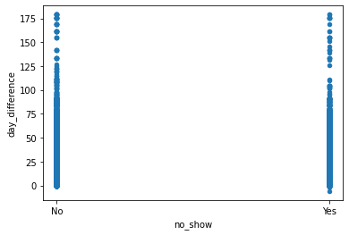

- There are many people with a few days difference also missed their appointments as shown above and vice versa.

# Which disease the hospital cares about most and sent them an SMS?

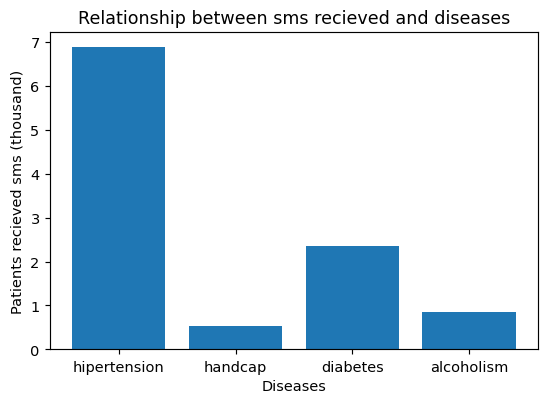

# Now, let's focus on the patients who missed their scheduled appointments.

## What percentages of males and females missed appointments?

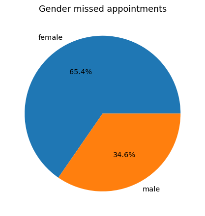

- Female patients seem to be missing their appointments more than males, which is predicted because the number of females is almost twice that of males in all the dataset.

# When, month and week-day, do they miss their appointments?

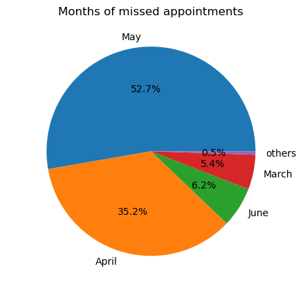

- Maybe people in *Brazil* are so busy in *May* and *April* that they missed their scheduled appointments.

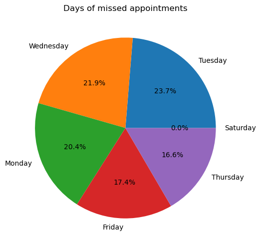

- In Brazil, the weekend is Saturday and Sunday when there are almost no canceled appointments on weekends.

# What is the month when patients have most appointments in the hospital?

# Which hospital has maximum number of appointments that day?

- Data analysis shows that:

```
The most crowded month is May which has 67421 visits.
```

```
The most crowded neighbourhood is Jardim Camburi.
```

# Is there a relationship between age of patient and enrollment in Brasilian welfare program Bolsa Família?

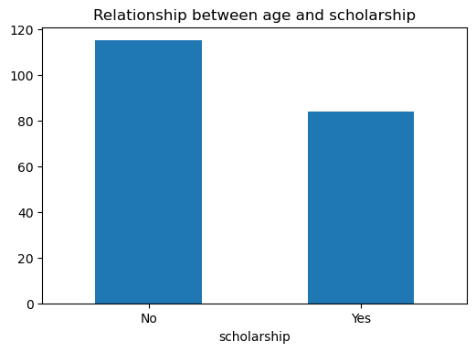